# 220112_gbm_deseq2_transfer_learning

Jennifer Fisher

1/12/2022

# START

```
Goal/Purpose of operations:
I am taking the latent variables from PLIER for GBM and applying it to the GBM tumor and controls. Also using GTEX controls for this experiment, so I am not only looking at 5 controls. Note DESeq2 was also applied in this script

Finished psedocode on:
220112

System which operations were done on:
my laptop

GitHub Repo:
Transfer_Learning_R03

Docker/Singularity:
rstudio_cancer_dr

Directory of operations:
"/home/rstudio"

Scripts being edited for operations:
using some modified scripts from MultiPLIER paper

Data being used:
TCGA GBM data and GTEx Brain samples
PLIER output

Papers and tools:
limma and MultiPLIER
PCA analysis
DESeq2
```

# STEPS

### load in data

```r
library(recount3)
library(SummarizedExperiment)
library(dplyr)
```

load in function scripts

```r
source("/home/rstudio/script/functions_cancer_signature_reversion_JLF.R")
source("/home/rstudio/script/plier_util.R")
source("/home/rstudio/script/test_LV_differences.R")
```

Download GBM dataset: make raw count and metadata table

```r
human_projects<- available_projects()
```

```
## 2022-10-27 19:40:26 caching file sra.recount_project.MD.gz.
```

```
## 2022-10-27 19:40:27 caching file gtex.recount_project.MD.gz.
```

```
## 2022-10-27 19:40:27 caching file tcga.recount_project.MD.gz.
```

```r
recount3_rse_GBM <- create_rse(human_projects[(human_projects$project == "GBM"),])
```

```
## 2022-10-27 19:40:32 downloading and reading the metadata.
```

```
## 2022-10-27 19:40:32 caching file tcga.tcga.GBM.MD.gz.
```

```
## 2022-10-27 19:40:33 caching file tcga.recount_project.GBM.MD.gz.
```

```
## 2022-10-27 19:40:33 caching file tcga.recount_qc.GBM.MD.gz.
```

```
## 2022-10-27 19:40:34 caching file tcga.recount_seq_qc.GBM.MD.gz.
```

```
## 2022-10-27 19:40:35 downloading and reading the feature information.
```

```
## 2022-10-27 19:40:36 caching file human.gene_sums.G026.gtf.gz.
```

```
## 2022-10-27 19:40:37 downloading and reading the counts: 175 samples across 63856 features.
```

```
## 2022-10-27 19:40:37 caching file tcga.gene_sums.GBM.G026.gz.
```

```
## 2022-10-27 19:40:40 construcing the RangedSummarizedExperiment (rse) object.
```

tcgabiolinks download done by Avery Williams

```r
load("/home/rstudio/data/TCGA_GBM_GeneExpression_TCGABIOlinks.rda")
```

```r
metadata_gbm<- colData(data)
```

```r
table(metadata_gbm$paper_IDH.status)
```

```
##
## Mutant     WT
##     11    141
```

```r
#all primary tumors
 metadata_gbm$sample_type[ metadata_gbm$paper_IDH.status == "WT"]
```

```
##   [1] "Primary Tumor" "Primary Tumor" "Primary Tumor" "Primary Tumor"
##   [5] "Primary Tumor" "Primary Tumor" NA              NA
##   [9] NA              "Primary Tumor" "Primary Tumor" "Primary Tumor"
##  [13] "Primary Tumor" NA              NA              "Primary Tumor"
##  [17] "Primary Tumor" NA              "Primary Tumor" "Primary Tumor"
##  [21] "Primary Tumor" "Primary Tumor" "Primary Tumor" "Primary Tumor"
##  [25] "Primary Tumor" "Primary Tumor" "Primary Tumor" "Primary Tumor"
##  [29] NA              "Primary Tumor" "Primary Tumor" "Primary Tumor"
##  [33] "Primary Tumor" "Primary Tumor" "Primary Tumor" "Primary Tumor"
##  [37] "Primary Tumor" "Primary Tumor" "Primary Tumor" "Primary Tumor"
##  [41] "Primary Tumor" "Primary Tumor" "Primary Tumor" "Primary Tumor"
##  [45] "Primary Tumor" "Primary Tumor" "Primary Tumor" "Primary Tumor"
##  [49] "Primary Tumor" "Primary Tumor" "Primary Tumor" "Primary Tumor"
##  [53] "Primary Tumor" "Primary Tumor" "Primary Tumor" "Primary Tumor"
##  [57] "Primary Tumor" "Primary Tumor" "Primary Tumor" "Primary Tumor"
```

[output cut: 26 more lines]

141 wildtype GBM. mutant IDH are no longer GBM

```r
IDS <- metadata_gbm$barcode[ metadata_gbm$paper_IDH.status == "WT"]
IDS<- IDS[!is.na(IDS)]
#inculde the five nromal samples
nt<- metadata_gbm$barcode[ metadata_gbm$sample_type == "Solid Tissue Normal"]
IDS<- c(IDS, nt)
```

```r
recount_metadata<- colData(recount3_rse_GBM)
recount_metadata<- as.data.frame(recount_metadata)
```

```r
recount_1ds<- rownames(recount_metadata)[recount_metadata$tcga.tcga_barcode %in% IDS]
```

```r
recount3_count_GBM <- as.data.frame(assay(recount3_rse_GBM))
```

```r
recount3_count_GBM<- recount3_count_GBM[,colnames(recount3_count_GBM) %in% recount_1ds]
```

Download GTEx Brain dataset: make raw count and metadata table

```r
recount3_rse_BRIAN <- create_rse(human_projects[(human_projects$project == "BRAIN"),])
```

```
## 2022-10-27 19:40:42 downloading and reading the metadata.
```

```
## 2022-10-27 19:40:42 caching file gtex.gtex.BRAIN.MD.gz.
```

```
## 2022-10-27 19:40:43 caching file gtex.recount_project.BRAIN.MD.gz.
```

```
## 2022-10-27 19:40:43 caching file gtex.recount_qc.BRAIN.MD.gz.
```

```
## 2022-10-27 19:40:44 caching file gtex.recount_seq_qc.BRAIN.MD.gz.
```

```
## 2022-10-27 19:40:45 downloading and reading the feature information.
```

```
## 2022-10-27 19:40:45 caching file human.gene_sums.G026.gtf.gz.
```

```
## 2022-10-27 19:40:46 downloading and reading the counts: 2931 samples across 63856 features.
```

```
## 2022-10-27 19:40:47 caching file gtex.gene_sums.BRAIN.G026.gz.
```

```
## 2022-10-27 19:41:05 construcing the RangedSummarizedExperiment (rse) object.
```

```r
recount3_count_brain<- assay(recount3_rse_BRIAN)
recount3_count_brain <- as.data.frame(recount3_count_brain)
```

### Analysis

#pca analysis of both datasets

TCGA GBM PCA analysis

```r
library(DESeq2)
vst_table <- vst(as.matrix(recount3_count_GBM))
vst_table_df <- t(vst_table)
pca.tumor <- prcomp(vst_table_df)
```

```r
summary(pca.tumor)
```

```
## Importance of components:
##                            PC1      PC2      PC3      PC4      PC5      PC6
## Standard deviation     62.4811 46.16830 37.96782 35.78929 34.39633 29.38990
## Proportion of Variance  0.1506  0.08223  0.05561  0.04941  0.04564  0.03332
## Cumulative Proportion   0.1506  0.23282  0.28843  0.33784  0.38348  0.41680
##                             PC7      PC8      PC9     PC10     PC11    PC12
## Standard deviation     27.23336 22.93575 21.64234 20.67196 19.71296 18.8462
## Proportion of Variance  0.02861  0.02029  0.01807  0.01648  0.01499  0.0137
## Cumulative Proportion   0.44541  0.46571  0.48377  0.50026  0.51525  0.5290
##                            PC13     PC14     PC15     PC16     PC17     PC18
## Standard deviation     17.81628 17.15042 16.69554 16.50891 16.03503 15.78214
## Proportion of Variance  0.01224  0.01135  0.01075  0.01051  0.00992  0.00961
## Cumulative Proportion   0.54120  0.55254  0.56330  0.57381  0.58373  0.59334
##                            PC19     PC20     PC21     PC22     PC23     PC24
## Standard deviation     15.60032 15.42056 14.75005 14.47256 14.23074 14.17340
## Proportion of Variance  0.00939  0.00917  0.00839  0.00808  0.00781  0.00775
## Cumulative Proportion   0.60272  0.61190  0.62029  0.62837  0.63618  0.64393
##                            PC25     PC26     PC27    PC28     PC29     PC30
## Standard deviation     13.68197 13.22094 13.12952 12.7805 12.54994 12.37492
## Proportion of Variance  0.00722  0.00674  0.00665  0.0063  0.00608  0.00591
## Cumulative Proportion   0.65115  0.65790  0.66455  0.6708  0.67692  0.68283
##                            PC31     PC32     PC33     PC34     PC35     PC36
## Standard deviation     12.21172 11.99659 11.82558 11.66650 11.50664 11.44779
## Proportion of Variance  0.00575  0.00555  0.00539  0.00525  0.00511  0.00506
## Cumulative Proportion   0.68858  0.69413  0.69953  0.70478  0.70989  0.71494
##                            PC37     PC38     PC39     PC40     PC41     PC42
## Standard deviation     11.32864 11.21076 11.06269 10.92662 10.87663 10.78848
## Proportion of Variance  0.00495  0.00485  0.00472  0.00461  0.00456  0.00449
## Cumulative Proportion   0.71989  0.72474  0.72946  0.73407  0.73863  0.74312
##                            PC43     PC44     PC45     PC46     PC47     PC48
## Standard deviation     10.74491 10.61537 10.46440 10.31849 10.19358 10.14005
## Proportion of Variance  0.00445  0.00435  0.00422  0.00411  0.00401  0.00397
## Cumulative Proportion   0.74758  0.75192  0.75615  0.76025  0.76426  0.76823
##                            PC49     PC50    PC51   PC52    PC53   PC54    PC55
## Standard deviation     10.11966 10.02198 9.97956 9.9315 9.80993 9.6658 9.61182
## Proportion of Variance  0.00395  0.00387 0.00384 0.0038 0.00371 0.0036 0.00356
## Cumulative Proportion   0.77218  0.77605 0.77990 0.7837 0.78741 0.7910 0.79458
##                           PC56    PC57    PC58    PC59    PC60    PC61    PC62
## Standard deviation     9.53548 9.45831 9.41391 9.37098 9.20537 9.16720 9.13145
## Proportion of Variance 0.00351 0.00345 0.00342 0.00339 0.00327 0.00324 0.00322
```

[output cut: 38 more lines]

```
## Standard deviation     6.80535 6.77157 6.71091 6.66863 6.65402 6.62860 6.58933
## Proportion of Variance 0.00179 0.00177 0.00174 0.00172 0.00171 0.00169 0.00167
## Cumulative Proportion  0.97117 0.97294 0.97468 0.97640 0.97810 0.97980 0.98147
##                          PC133   PC134   PC135   PC136   PC137   PC138  PC139
## Standard deviation     6.53522 6.47664 6.45147 6.39107 6.33146 6.32883 6.2273
## Proportion of Variance 0.00165 0.00162 0.00161 0.00158 0.00155 0.00155 0.0015
## Cumulative Proportion  0.98312 0.98474 0.98634 0.98792 0.98947 0.99101 0.9925
##                          PC140   PC141   PC142   PC143   PC144   PC145
## Standard deviation     6.15588 6.09786 5.98833 5.73040 5.18867 4.85013
## Proportion of Variance 0.00146 0.00143 0.00138 0.00127 0.00104 0.00091
## Cumulative Proportion  0.99397 0.99540 0.99679 0.99805 0.99909 1.00000
##                            PC146
## Standard deviation     1.594e-13
## Proportion of Variance 0.000e+00
## Cumulative Proportion  1.000e+00
```

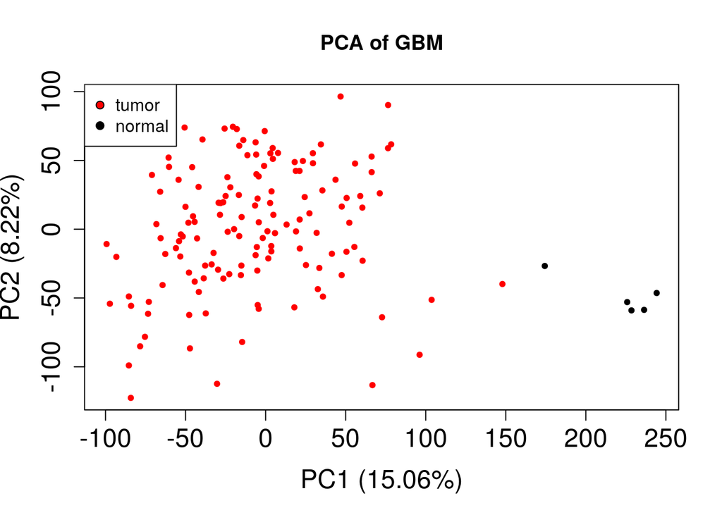

```r
normal_ids<- rownames(recount_metadata)[recount_metadata$tcga.tcga_barcode %in% nt]

tumor_norm <- ifelse(colnames(recount3_count_GBM) %in% normal_ids, "black", "red")
plot(pca.tumor$x[, 1], pca.tumor$x[, 2], pch = 20, col = tumor_norm  , main = "PCA of GBM", xlab = "PC1 (15.06%)", ylab = "PC2 (8.22%)", cex.axis = "1.5", cex.lab = "1.5")
legend("topleft", legend = c("tumor", "normal"), pch = 21, pt.bg = c("red", "black"), col = "black")
```

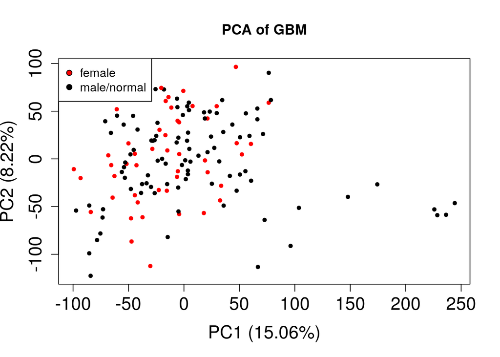

```r
sex<- metadata_gbm$barcode[metadata_gbm$gender == "female"]
sex<- sex[!is.na(sex)]
normal_ids<- rownames(recount_metadata)[recount_metadata$tcga.tcga_barcode %in% sex]

tumor_norm <- ifelse(colnames(recount3_count_GBM) %in% normal_ids, "red", "black")
plot(pca.tumor$x[, 1], pca.tumor$x[, 2], pch = 20, col = tumor_norm  , main = "PCA of GBM", xlab = "PC1 (15.06%)", ylab = "PC2 (8.22%)", cex.axis = "1.5", cex.lab = "1.5")
legend("topleft", legend = c("female", "male/normal"), pch = 21, pt.bg = c("red", "black"), col = "black")
```

no large covariates to account for in analysis

GTEx Brain PCA analysis

```r
library(DESeq2)
vst_table <- vst(as.matrix(recount3_count_brain))
vst_table_df <- t(vst_table)
pca.brain <- prcomp(vst_table_df)
```

```r
eigs <- pca.brain$sdev^2
summ <- rbind(
  SD = sqrt(eigs),
  Proportion = eigs/sum(eigs),
  Cumulative = cumsum(eigs)/sum(eigs))
```

```r
summ[,1:10]
```

```
##                  [,1]       [,2]        [,3]        [,4]        [,5]
## SD         82.5824260 58.5271856 37.54680859 30.26356908 26.98719784
## Proportion  0.2818953  0.1415884  0.05827182  0.03785758  0.03010427
## Cumulative  0.2818953  0.4234837  0.48175553  0.51961311  0.54971738
##                   [,6]        [,7]        [,8]        [,9]       [,10]
## SD         24.65724193 22.07698488 20.35644216 18.20959975 16.63520066
## Proportion  0.02513052  0.02014615  0.01712838  0.01370608  0.01143849
## Cumulative  0.57484790  0.59499405  0.61212243  0.62582851  0.63726700
```

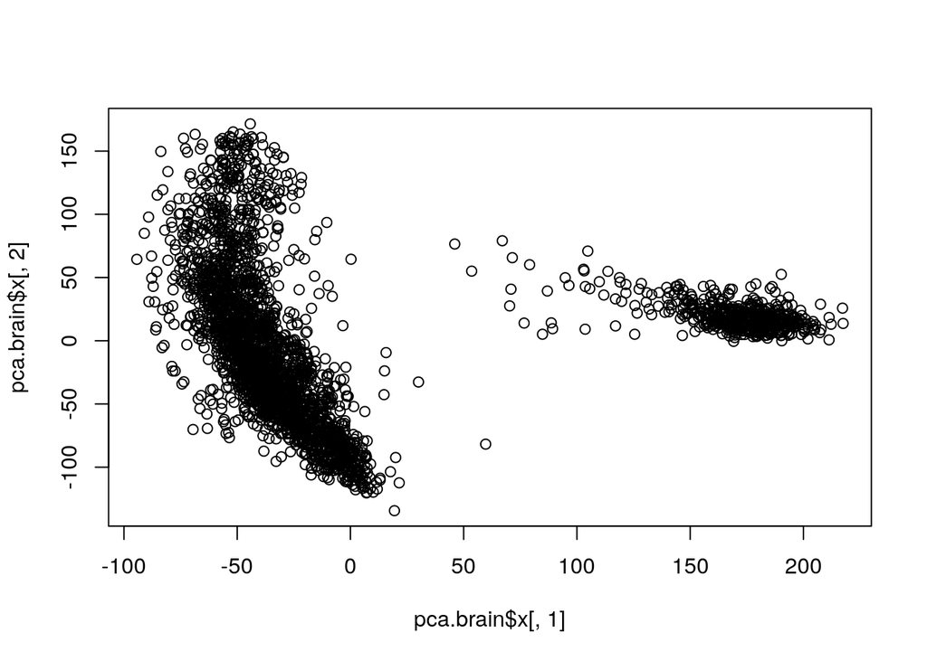

```r
plot(pca.brain$x[,1], pca.brain$x[,2])
```

```r
group_samples<- names(pca.brain$x[,1])[pca.brain$x[,1] >40]
```

```r
metadata_gtex<- as.data.frame(colData(recount3_rse_BRIAN))

metadata_gtex_pca1 <- metadata_gtex[rownames(metadata_gtex) %in% group_samples,]
metadata_gtex_pca1.2 <- metadata_gtex[!rownames(metadata_gtex) %in% group_samples,]
```

```r
table(metadata_gtex_pca1$gtex.smtsd)
```

```
##
##    Brain - Caudate (basal ganglia)      Brain - Cerebellar Hemisphere
##                                  1                                244
##                 Brain - Cerebellum                     Brain - Cortex
##                                283                                  2
##               Brain - Hypothalamus Brain - Spinal cord (cervical c-1)
##                                  2                                  1
```

```r
table(metadata_gtex_pca1.2$gtex.smtsd)
```

```
##
##                          Brain - Amygdala
##                                       163
##  Brain - Anterior cingulate cortex (BA24)
##                                       201
##           Brain - Caudate (basal ganglia)
##                                       272
##             Brain - Cerebellar Hemisphere
##                                         6
##                        Brain - Cerebellum
##                                         2
##                            Brain - Cortex
##                                       284
##              Brain - Frontal Cortex (BA9)
##                                       224
##                       Brain - Hippocampus
##                                       220
##                      Brain - Hypothalamus
##                                       219
## Brain - Nucleus accumbens (basal ganglia)
##                                       262
##           Brain - Putamen (basal ganglia)
##                                       221
##        Brain - Spinal cord (cervical c-1)
##                                       170
##                  Brain - Substantia nigra
##                                       154
```

```r
table(metadata_gtex_pca1$gtex.sex)
```

```
##
##   1   2
## 380 153
```

```r
table(metadata_gtex_pca1.2$gtex.sex)
```

```
##
##    1    2
## 1715  683
```

note that brain structures are a major influence in the PCA, but I can not control this in DESeq2 or limma models because I don’t have this information in TCGA GBM samples

only covariate at this point is GTex vs TCGA databases

#GBM vs normal DESeq2

create metadata for DESeq2 - database, tumor/normal, subtype, sex

```r
#order the tcga data to match recount3 order
recount3_ids <- colnames(recount3_count_GBM)
recount_metadata_sub <- recount_metadata[rownames(recount_metadata) %in% recount3_ids,]
identical(rownames(recount_metadata_sub),recount3_ids)
```

```
## [1] TRUE
```

```r
ids <- recount_metadata_sub$tcga.tcga_barcode

nam <-
status<- c()
subtype<- c()
sex<- c()
for (i in 1:length(ids)){

nam[i]<- ids[i]
#create tumor/normal col
status[i] <-metadata_gbm$sample_type[metadata_gbm$barcode == ids[i]]
#create subtype col
subtype[i] <-as.character(metadata_gbm$paper_Transcriptome.Subtype[metadata_gbm$barcode == ids[i]])
subtype[i]<- ifelse(is.na(subtype[i]), "NA", subtype[i])
#create sex col
sex[i]<- metadata_gbm$gender[metadata_gbm$barcode == ids[i]]
}
#create database col
database <- rep("TCGA", 146)
#create metadata
tcga_gbm_metadata<- as.data.frame(cbind(nam, database, status, subtype, sex))
rownames(tcga_gbm_metadata)<- recount3_ids
tcga_gbm_metadata[1:5,]
```

```
##                                                               nam database
## 3b7f80e6-74a7-4da1-ac4b-c260b6be880a TCGA-06-0649-01B-01R-1849-01     TCGA
## 97a8e2b1-059b-4527-8fb4-116f718ffd16 TCGA-14-1823-01A-01R-1849-01     TCGA
## bb96c5ba-ca50-40b4-b22a-3fcfe46ab11c TCGA-28-5208-01A-01R-1850-01     TCGA
## 633064db-d3ed-4b5f-b48f-6924ad719647 TCGA-19-2619-01A-01R-1850-01     TCGA
## 4b93a447-e626-4040-9ba0-1eeab3764c6b TCGA-41-3915-01A-01R-1850-01     TCGA
##                                             status subtype    sex
## 3b7f80e6-74a7-4da1-ac4b-c260b6be880a Primary Tumor      ME female
## 97a8e2b1-059b-4527-8fb4-116f718ffd16 Primary Tumor      ME female
## bb96c5ba-ca50-40b4-b22a-3fcfe46ab11c Primary Tumor      CL   male
## 633064db-d3ed-4b5f-b48f-6924ad719647 Primary Tumor      CL female
## 4b93a447-e626-4040-9ba0-1eeab3764c6b Primary Tumor      ME   male
```

Look at how many of each

```r
table(tcga_gbm_metadata$status)
```

```
##
##       Primary Tumor Solid Tissue Normal
##                 141                   5
```

```r
table(tcga_gbm_metadata$subtype)
```

```
##
## CL ME NA NE PN
## 49 62 17  6 12
```

```r
table(tcga_gbm_metadata$sex)
```

```
##
## female   male
##     50     90
```

create metadata for GTEx

```r
#order the metadata to match recount3 order

#create sex col
identical (rownames(metadata_gtex), colnames( recount3_count_brain))
```

```
## [1] TRUE
```